# Tugas 1 MPDW

Dinda Khamila Nurfatimah

2023-09-04

## library

```r
library("forecast")
```

```r
library("graphics")
library("TTR")
library("TSA")
```

## Impor Data

```r
library(rio)
data <- import("https://raw.githubusercontent.com/DindaKhamila/mpdw/main/Data/DataTugas.csv")
```

## Eksplorasi Data

```r
View(data) #untuk melihat data
str(data) #untuk melihat struktur data
```

```
## 'data.frame':    359 obs. of  2 variables:
##  $ Waktu        : int  1 2 3 4 5 6 7 8 9 10 ...
##  $ PowerConsumed: num  85.8 85.5 83.5 79.2 76.6 71.1 69 89.2 92.8 79.5 ...
```

```r
dim(data) #untuk melihat dimensi data
```

```
## [1] 359   2
```

## Mengubah data agar terbaca sebagai data deret waktu dengan fungsi `ts()` .

```r
data.ts <- ts(data$PowerConsumed)
data.ts
```

```
## Time Series:
## Start = 1
## End = 359
## Frequency = 1
##   [1]  85.8  85.5  83.5  79.2  76.6  71.1  69.0  89.2  92.8  79.5  92.6  89.4
##  [13]  82.2  77.8 111.8 115.6 117.9 121.9 121.7 112.2 108.0 109.3 111.9 114.2
##  [25] 112.7 105.0 100.5  96.4  41.8  43.1  42.9  44.9  43.8  43.5  44.1  60.3
##  [37]  63.2  68.4  67.6  69.0  64.8  61.2  71.8  71.7  72.7  71.6  71.3  69.2
##  [49]  67.0 111.8 114.9 121.6 128.1 131.6 132.2 132.7  69.0  72.1  71.8  71.1
##  [61]  73.0  68.0  67.3 111.7 121.6 128.0 132.7 132.6 129.7 113.9  57.8  51.2
##  [73]  58.4  63.0  66.1  69.6  68.3  62.5  63.5  62.6  62.4  63.5  60.4  57.2
##  [85]  61.7  64.3  65.9  67.4  71.8  73.9  69.1  61.4  64.1  66.1  66.1  65.4
##  [97]  63.0  60.2 123.2 126.1 135.1 135.2 133.5 136.7 136.0  63.9  63.6  63.8
## [109]  62.5  63.8  60.3  57.9  74.2  76.9  76.9  79.2  82.0  80.4  78.0  98.5
## [121]  99.3 102.4 102.6 100.9  94.6  84.7 116.6 129.0 130.4 115.2 109.3 100.7
```

[output cut: 19 more lines]

## Menampilkan ringkasan data

```r
summary(data.ts)
```

```
##    Min. 1st Qu.  Median    Mean 3rd Qu.    Max.
##   41.80   63.40   72.50   82.06  102.25  139.10
```

## Membuat plot data deret waktu

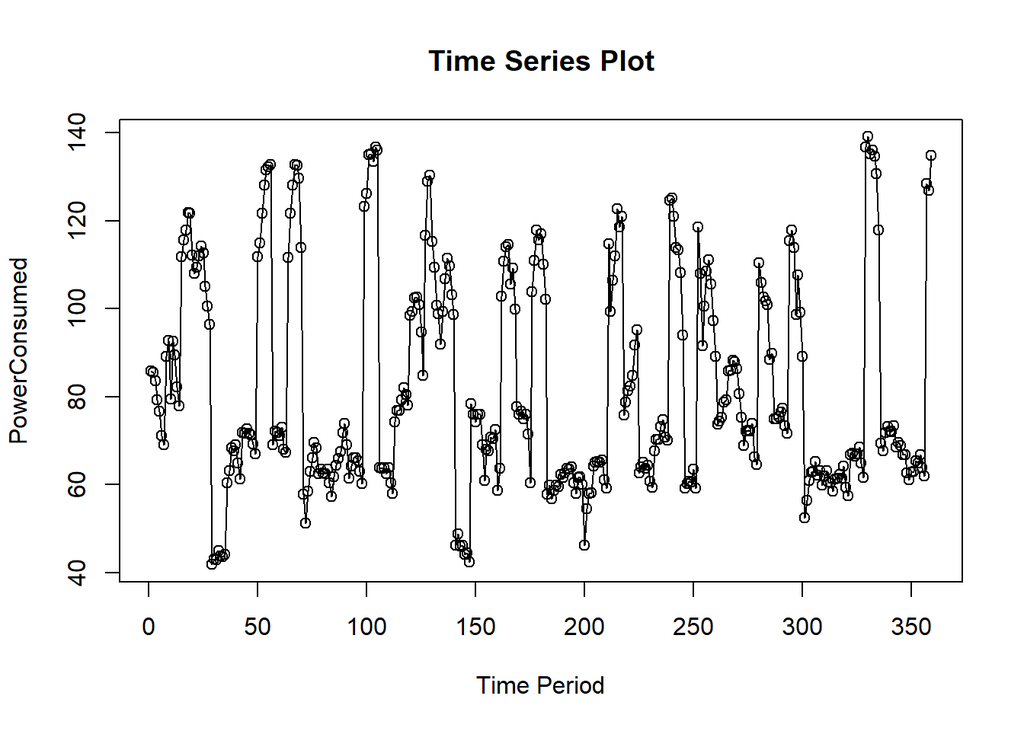

```r
ts.plot(data.ts, xlab="Time Period", ylab="PowerConsumed",
        main = "Time Series Plot")
points(data.ts)
```

Kemungkinan pola yang terbentuk dari data adalah pola stasioner atau musiman. Untuk itu, saya akan coba bandingkan dengan metode SMA dan SES untuk pola stasioner serta Winter Multiplikatif untuk pola musiman.

## Single Moving Average

### Pembagian Data

Pembagian data latih dan data uji dilakukan dengan perbandingan 80% data latih dan 20% data uji.

```r
#membagi data latih dan data uji
training_ma <- data[1:287,]
testing_ma <- data[288:359,]
train_ma.ts <- ts(training_ma$PowerConsumed)
test_ma.ts <- ts(testing_ma$PowerConsumed)
```

### Eksplorasi Data

Eksplorasi data dilakukan pada keseluruhan data, data latih serta data uji menggunakan plot data deret waktu.

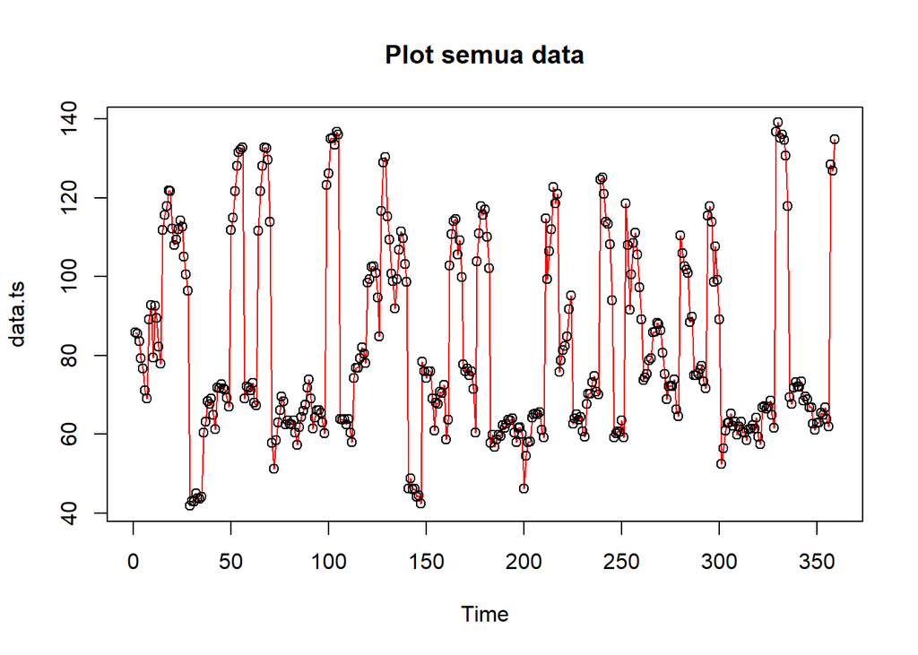

```r
#eksplorasi keseluruhan data
plot(data.ts, col="red",main="Plot semua data")
points(data.ts)
```

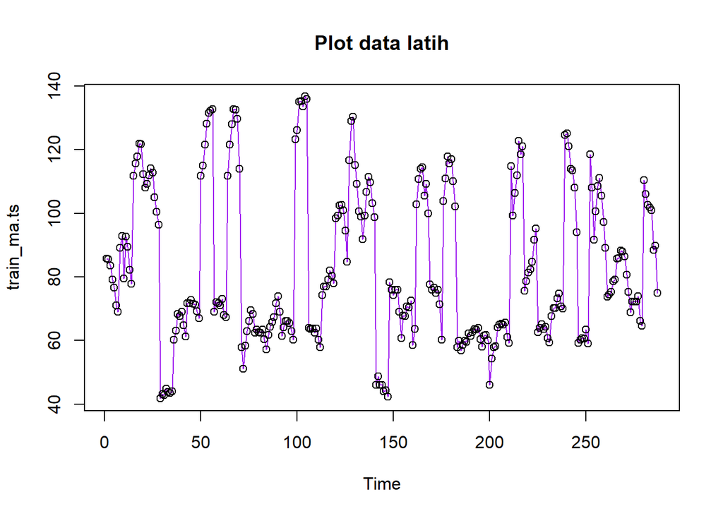

```r
#eksplorasi data latih
plot(train_ma.ts, col="purple",main="Plot data latih")
points(train_ma.ts)
```

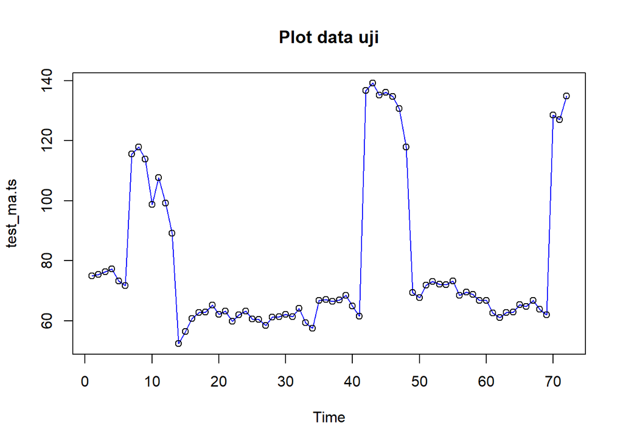

```r
#eksplorasi data uji
plot(test_ma.ts, col="blue",main="Plot data uji")
points(test_ma.ts)
```

Eksplorasi data juga dapat dilakukan menggunakan package `ggplot2` dengan terlebih dahulu memanggil library *package* `ggplot2`.

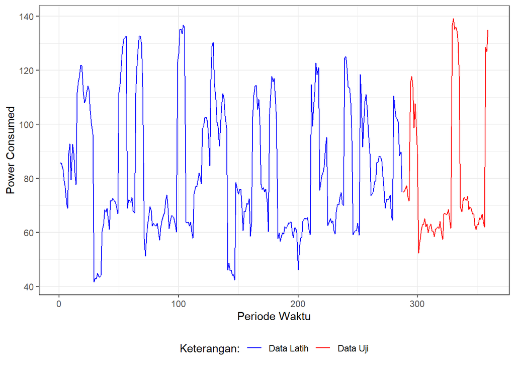

```r
#Eksplorasi dengan GGPLOT
library(ggplot2)
ggplot() +
  geom_line(data = training_ma, aes(x = Waktu, y = PowerConsumed, col = "Data Latih")) +
  geom_line(data = testing_ma, aes(x = Waktu, y = PowerConsumed, col = "Data Uji")) +
  labs(x = "Periode Waktu", y = "Power Consumed", color = "Legend") +
  scale_colour_manual(name="Keterangan:", breaks = c("Data Latih", "Data Uji"),
                      values = c("blue", "red")) +
  theme_bw() + theme(legend.position = "bottom",
                     plot.caption = element_text(hjust=0.5, size=12))
```

### Single Moving Average (SMA)

Ide dasar dari Single Moving Average (SMA) adalah data suatu periode dipengaruhi oleh data periode sebelumnya. Metode pemulusan ini cocok digunakan untuk pola data stasioner atau konstan. Prinsip dasar metode pemulusan ini adalah data pemulusan pada periode ke-t merupakan rata rata dari m buah data pada periode ke-t hingga periode ke (t-m+1). Data pemulusan pada periode ke-t selanjutnya digunakan sebagai nilai peramalan pada periode ke t+1

Pemulusan menggunakan metode SMA dilakukan dengan fungsi `SMA()`. Dalam hal ini akan dilakukan pemulusan dengan parameter `m=4`.

```r
data.sma<-SMA(train_ma.ts, n=4)
data.sma
```

```
## Time Series:
## Start = 1
## End = 287
## Frequency = 1
##   [1]      NA      NA      NA  83.500  81.200  77.600  73.975  76.475  80.525
##  [10]  82.625  88.525  88.575  85.925  85.500  90.300  96.850 105.775 116.800
##  [19] 119.275 118.425 115.950 112.800 110.350 110.850 112.025 110.950 108.100
##  [28] 103.650  85.925  70.450  56.050  43.175  43.675  43.775  44.075  47.925
##  [37]  52.775  59.000  64.875  67.050  67.450  65.650  66.700  67.375  69.350
##  [46]  71.950  71.825  71.200  69.775  79.825  90.725 103.825 119.100 124.050
##  [55] 128.375 131.150 116.375 101.500  86.400  71.000  72.000  70.975  69.850
##  [64]  80.000  92.150 107.150 123.500 128.725 130.750 127.225 108.500  88.150
##  [73]  70.325  57.600  59.675  64.275  66.750  66.625  65.975  64.225  62.750
##  [82]  63.000  62.225  60.875  60.700  60.900  62.275  64.825  67.350  69.750
##  [91]  70.550  69.050  67.125  65.175  64.425  65.425  65.150  63.675  77.950
```

[output cut: 21 more lines]

Data pemulusan pada periode ke-t selanjutnya digunakan sebagai nilai peramalan pada periode ke t+1 sehingga hasil peramalan 1 periode kedepan adalah sebagai berikut.

```r
data.ramal<-c(NA,data.sma)
data.ramal #forecast 1 periode ke depan
```

```
##   [1]      NA      NA      NA      NA  83.500  81.200  77.600  73.975  76.475
##  [10]  80.525  82.625  88.525  88.575  85.925  85.500  90.300  96.850 105.775
##  [19] 116.800 119.275 118.425 115.950 112.800 110.350 110.850 112.025 110.950
##  [28] 108.100 103.650  85.925  70.450  56.050  43.175  43.675  43.775  44.075
##  [37]  47.925  52.775  59.000  64.875  67.050  67.450  65.650  66.700  67.375
##  [46]  69.350  71.950  71.825  71.200  69.775  79.825  90.725 103.825 119.100
##  [55] 124.050 128.375 131.150 116.375 101.500  86.400  71.000  72.000  70.975
##  [64]  69.850  80.000  92.150 107.150 123.500 128.725 130.750 127.225 108.500
##  [73]  88.150  70.325  57.600  59.675  64.275  66.750  66.625  65.975  64.225
##  [82]  62.750  63.000  62.225  60.875  60.700  60.900  62.275  64.825  67.350
##  [91]  69.750  70.550  69.050  67.125  65.175  64.425  65.425  65.150  63.675
## [100]  77.950  93.125 111.150 129.900 132.475 135.125 135.350 117.525 100.050
## [109]  81.825  63.450  63.425  62.600  61.125  64.050  67.325  71.475  76.800
## [118]  78.750  79.625  79.900  84.725  89.050  94.550 100.700 101.300 100.125
## [127]  95.700  99.200 106.225 115.175 122.800 120.975 113.900 106.025 100.200
```

[output cut: 17 more lines]

```r
data.gab<-cbind(aktual=c(train_ma.ts,rep(NA,72)),pemulusan=c(data.sma,rep(NA,72)),ramalan=c(data.ramal,rep(data.ramal[length(data.ramal)],71)))
data.gab #forecast 72 periode ke depan
```

```
##        aktual pemulusan ramalan
##   [1,]   85.8        NA      NA
##   [2,]   85.5        NA      NA
##   [3,]   83.5        NA      NA
##   [4,]   79.2    83.500      NA
##   [5,]   76.6    81.200  83.500
##   [6,]   71.1    77.600  81.200
##   [7,]   69.0    73.975  77.600
##   [8,]   89.2    76.475  73.975
##   [9,]   92.8    80.525  76.475
##  [10,]   79.5    82.625  80.525
##  [11,]   92.6    88.525  82.625
##  [12,]   89.4    88.575  88.525
##  [13,]   82.2    85.925  88.575
##  [14,]   77.8    85.500  85.925
```

[output cut: 345 more lines]

Adapun plot data deret waktu dari hasil peramalan yang dilakukan adalah sebagai berikut.

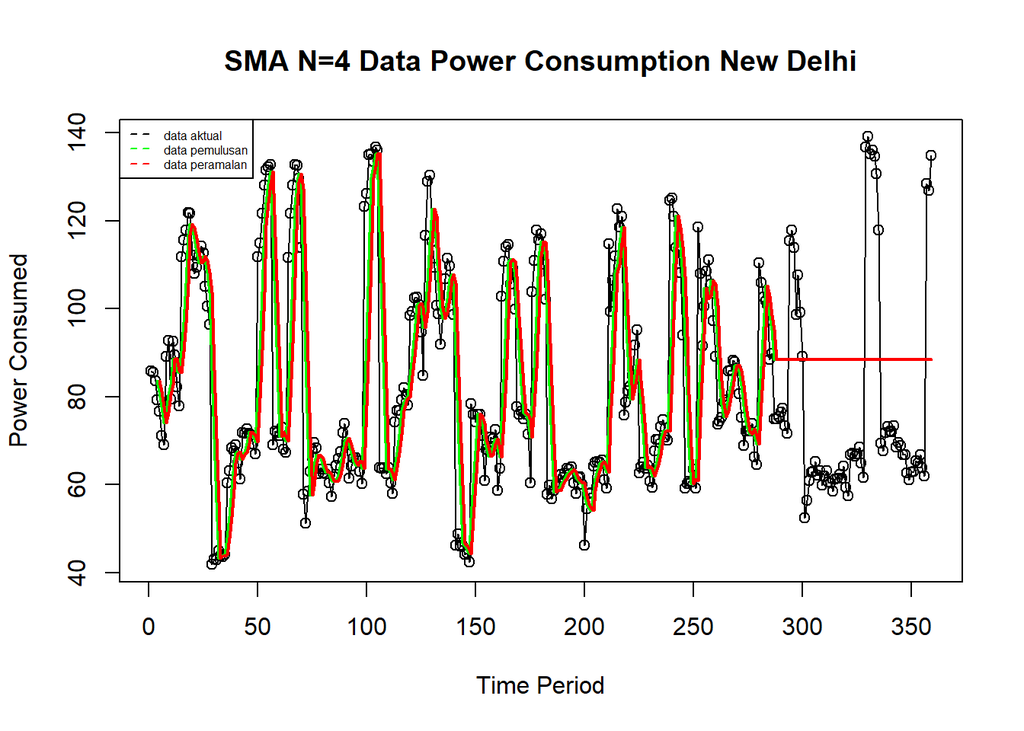

```r
ts.plot(data.ts, xlab="Time Period", ylab="Power Consumed", main= "SMA N=4 Data Power Consumption New Delhi")
points(data.ts)
lines(data.gab[,2],col="green",lwd=2)
lines(data.gab[,3],col="red",lwd=2)
legend("topleft",c("data aktual","data pemulusan","data peramalan"), lty=8, col=c("black","green","red"), cex=0.5)
```

Selanjutnya perhitungan akurasi dilakukan dengan ukuran akurasi *Sum Squares Error* (SSE), *Mean Square Error* (MSE) dan *Mean Absolute Percentage Error* (MAPE). Perhitungan akurasi dilakukan baik pada data latih maupun pada data uji.

```r
#Menghitung nilai keakuratan data latih
error_train.sma = train_ma.ts-data.ramal[1:length(train_ma.ts)]
SSE_train.sma = sum(error_train.sma[5:length(train_ma.ts)]^2)
MSE_train.sma = mean(error_train.sma[5:length(train_ma.ts)]^2)
MAPE_train.sma = mean(abs((error_train.sma[5:length(train_ma.ts)]/train_ma.ts[5:length(train_ma.ts)])*100))

akurasi_train.sma <- matrix(c(SSE_train.sma, MSE_train.sma, MAPE_train.sma))
row.names(akurasi_train.sma)<- c("SSE", "MSE", "MAPE")
colnames(akurasi_train.sma) <- c("Akurasi m = 4")
akurasi_train.sma
```

```
##      Akurasi m = 4
## SSE    113437.9662
## MSE       400.8409
## MAPE       17.2256
```

Dalam hal ini nilai MAPE data latih pada metode pemulusan SMA kurang dari 20%, yaitu sebesar 17,2256%, nilai ini dapat dikategorikan sebagai nilai akurasi yang baik. Selanjutnya dilakukan perhitungan nilai MAPE data uji pada metode pemulusan SMA.

```r
#Menghitung nilai keakuratan data uji
error_test.sma = test_ma.ts-data.gab[288:359,3]
SSE_test.sma = sum(error_test.sma^2)
MSE_test.sma = mean(error_test.sma^2)
MAPE_test.sma = mean(abs((error_test.sma/test_ma.ts*100)))

akurasi_test.sma <- matrix(c(SSE_test.sma, MSE_test.sma, MAPE_test.sma))
row.names(akurasi_test.sma)<- c("SSE", "MSE", "MAPE")
colnames(akurasi_test.sma) <- c("Akurasi m = 4")
akurasi_test.sma
```

```
##      Akurasi m = 4
## SSE    52868.27000
## MSE      734.28153
## MAPE      33.63032
```

Metode *Exponential Smoothing* adalah metode pemulusan dengan melakukan pembobotan menurun secara eksponensial. Nilai yang lebih baru diberi bobot yang lebih besar dari nilai terdahulu. Terdapat satu atau lebih parameter pemulusan yang ditentukan secara eksplisit, dan hasil pemilihan parameter tersebut akan menentukan bobot yang akan diberikan pada nilai pengamatan. Ada dua macam model, yaitu model tunggal dan ganda.

### Pembagian Data

```r
#membagi training dan testing
training<-data[1:287,]
testing<-data[288:359,]
train.ts <- ts(testing$PowerConsumed)
test.ts <- ts(testing$PowerConsumed)
```

### Eksplorasi

Eksplorasi dilakukan dengan membuat plot data deret waktu untuk keseluruhan data, data latih, dan data uji.

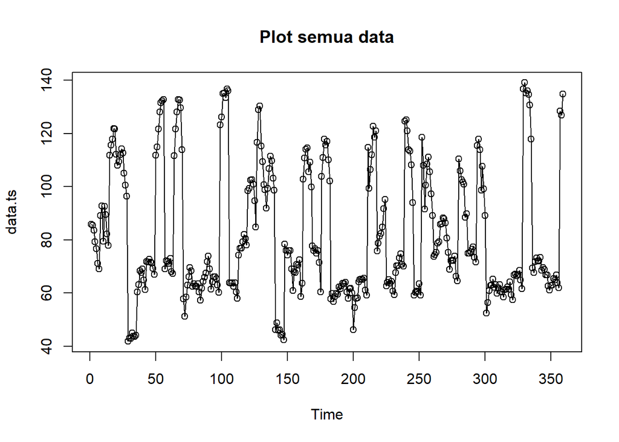

```r
#eksplorasi data
plot(data.ts, col="black",main="Plot semua data")
points(data.ts)
```

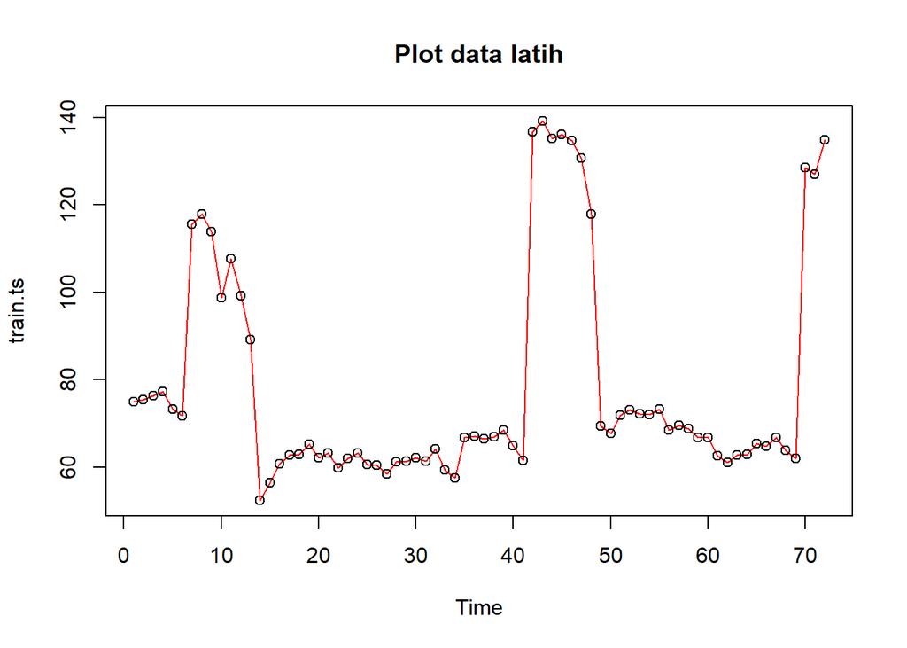

```r
plot(train.ts, col="red",main="Plot data latih")
points(train.ts)
```

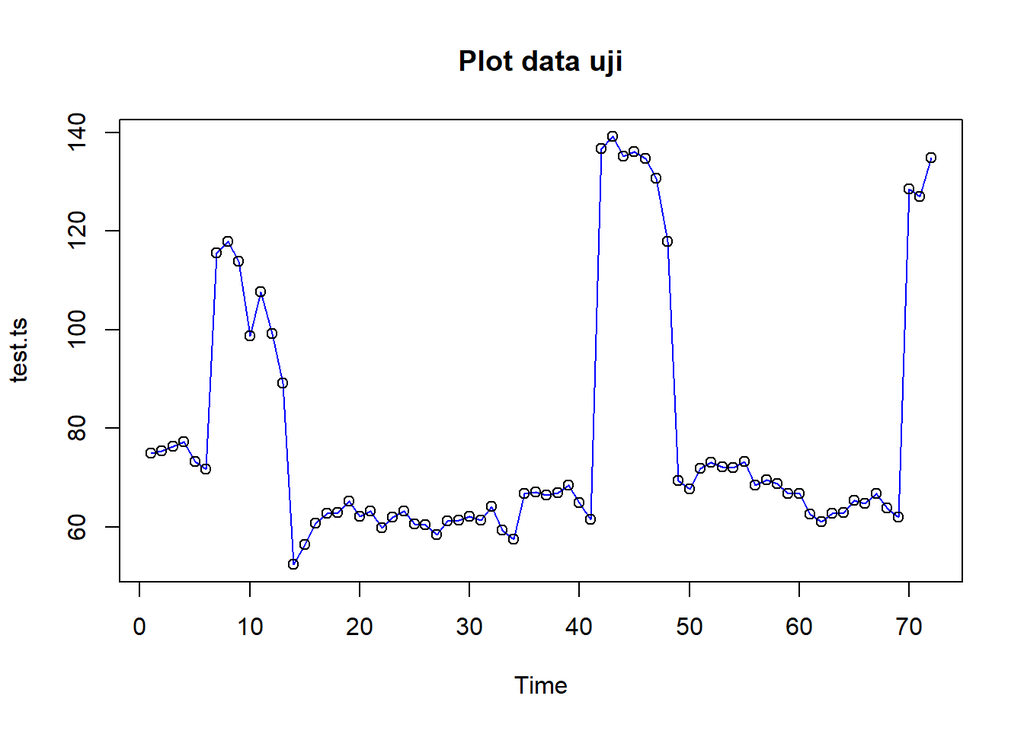

```r
plot(test.ts, col="blue",main="Plot data uji")
points(test.ts)
```

Eksplorasi data juga dapat dilakukan menggunakan package `ggplot2` .

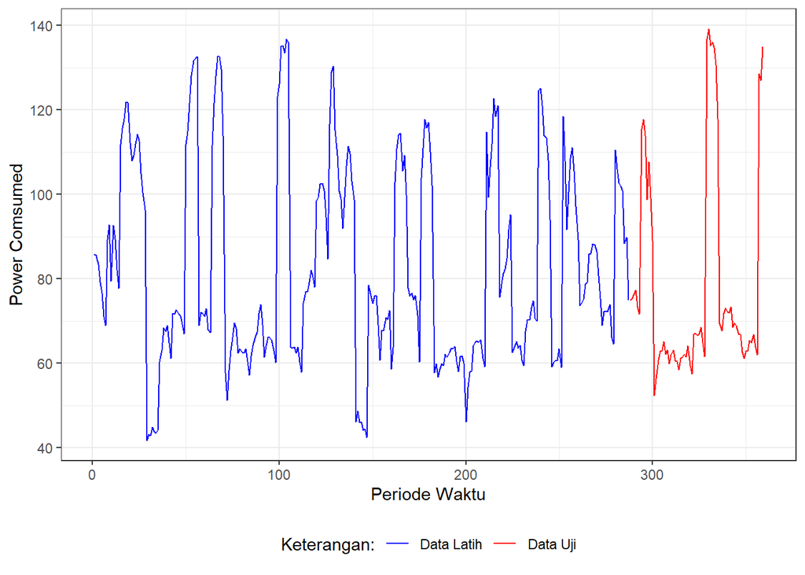

```r
#Eksplorasi dengan GGPLOT
library(ggplot2)
ggplot() +
  geom_line(data = training, aes(x = Waktu, y = PowerConsumed, col = "Data Latih")) +
  geom_line(data = testing, aes(x = Waktu, y = PowerConsumed, col = "Data Uji")) +
  labs(x = "Periode Waktu", y = "Power Comsumed", color = "Legend") +
  scale_colour_manual(name="Keterangan:", breaks = c("Data Latih", "Data Uji"),
                      values = c("blue", "red")) +
  theme_bw() + theme(legend.position = "bottom",
                     plot.caption = element_text(hjust=0.5, size=12))
```

### SES

Single Exponential Smoothing merupakan metode pemulusan yang tepat digunakan untuk data dengan pola stasioner atau konstan.

Nilai pemulusan pada periode ke-t didapat dari persamaan:

$$\tilde{y}_T=\lambda y_t+(1-\lambda)\tilde{y}_{T-1}$$

Nilai parameter $\lambda$ adalah nilai antara 0 dan 1.

Nilai pemulusan periode ke-t bertindak sebagai nilai ramalan pada periode ke-$(T+\tau)$.

$$\tilde{y}_{T+\tau}(T)=\tilde{y}_T$$

Pemulusan dengan metode SES dapat dilakukan dengan dua fungsi dari *packages* berbeda, yaitu (1) fungsi `ses()` dari *packages* `forecast` dan (2) fungsi `HoltWinters` dari *packages* `stats` .

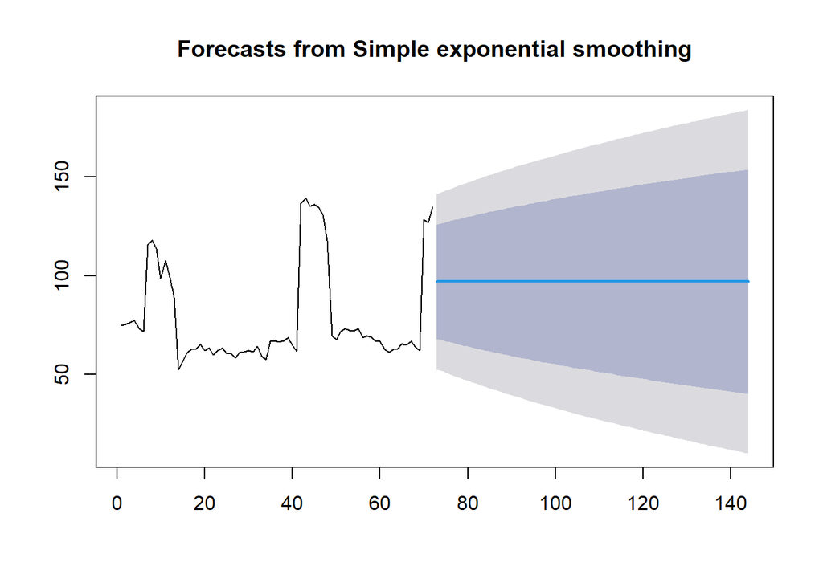

```r
#Cara 1 (fungsi ses)
ses.1<- ses(train.ts, h = 72, alpha = 0.2)
plot(ses.1)
```

```r
ses.1
```

```
##     Point Forecast    Lo 80    Hi 80     Lo 95    Hi 95
##  73       96.97275 67.94058 126.0049 52.571884 141.3736
##  74       96.97275 67.36563 126.5799 51.692573 142.2529
##  75       96.97275 66.80164 127.1439 50.830016 143.1155
##  76       96.97275 66.24799 127.6975 49.983290 143.9622
##  77       96.97275 65.70415 128.2413 49.151554 144.7939
##  78       96.97275 65.16960 128.7759 48.334038 145.6115
##  79       96.97275 64.64390 129.3016 47.530038 146.4155
##  80       96.97275 64.12660 129.8189 46.738904 147.2066
##  81       96.97275 63.61733 130.3282 45.960039 147.9855
##  82       96.97275 63.11572 130.8298 45.192887 148.7526
##  83       96.97275 62.62143 131.3241 44.436937 149.5086
##  84       96.97275 62.13415 131.8113 43.691711 150.2538
##  85       96.97275 61.65359 132.2919 42.956765 150.9887
##  86       96.97275 61.17949 132.7660 42.231686 151.7138
```

[output cut: 58 more lines]

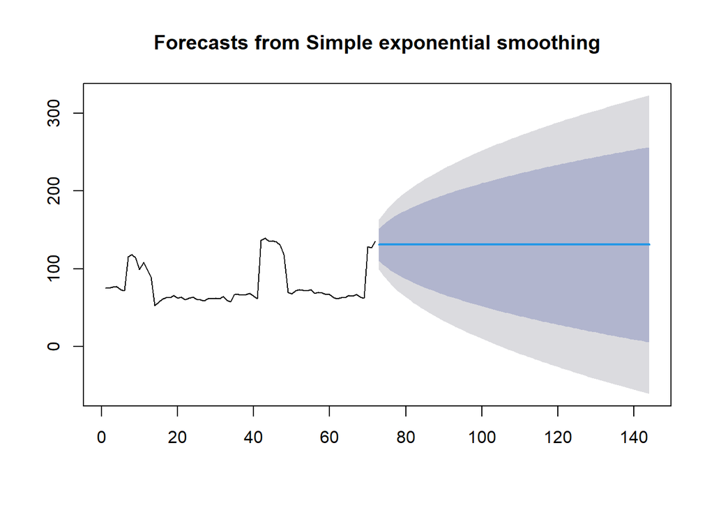

```r
ses.2<- ses(train.ts, h = 72, alpha = 0.7)
plot(ses.2)
```

```r
ses.2
```

```
##     Point Forecast      Lo 80    Hi 80        Lo 95    Hi 95
##  73       130.8689 109.908132 151.8296  98.81218603 162.9256
##  74       130.8689 105.283028 156.4547  91.73869994 169.9990
##  75       130.8689 101.374496 160.3632  85.76111640 175.9766
##  76       130.8689  97.926483 163.8113  80.48783523 181.2499
##  77       130.8689  94.806651 166.9311  75.71646393 186.0213
##  78       130.8689  91.936025 169.8017  71.32622034 190.4115
##  79       130.8689  89.262990 172.4748  67.23816701 194.4996
##  80       130.8689  86.751617 174.9861  63.39735305 198.3404
##  81       130.8689  84.375701 177.3620  59.76370257 201.9740
##  82       130.8689  82.115434 179.6223  56.30692211 205.4308
##  83       130.8689  79.955411 181.7823  53.00345206 208.7343
##  84       130.8689  77.883371 183.8544  49.83454055 211.9032
##  85       130.8689  75.889365 185.8484  46.78497268 214.9528
##  86       130.8689  73.965191 187.7726  43.84220151 217.8955
```

[output cut: 58 more lines]

Untuk mendapatkan gambar hasil pemulusan pada data latih dengan fungsi `ses()` , perlu digunakan fungsi `autoplot()` dan `autolayer()` dari *library packages* `ggplot2` .

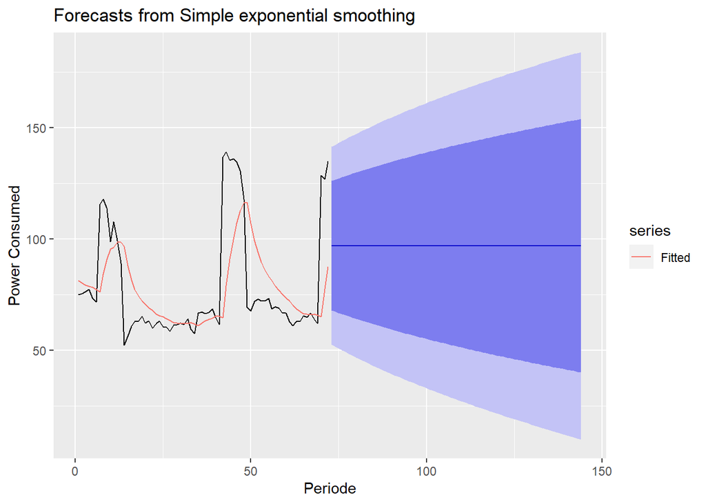

```r
autoplot(ses.1) +
  autolayer(fitted(ses.1), series="Fitted") +
  ylab("Power Consumed") + xlab("Periode")
```

Pada fungsi `ses()` , terdapat beberapa argumen yang umum digunakan, yaitu nilia `y` , `gamma` , `beta` , `alpha` , dan `h` .

Nilai `y` adalah nilai data deret waktu, `gamma` adalah parameter pemulusan untuk komponen musiman, `beta` adalah parameter pemulusan untuk tren, dan `alpha` adalah parameter pemulusan untuk stasioner, serta `h` adalah banyaknya periode yang akan diramalkan.

Kasus di atas merupakan contoh inisialisasi nilai parameter $\lambda$ dengan nilai `alpha` 0,2 dan 0,7 dan banyak periode data yang akan diramalkan adalah sebanyak 72 periode. Selanjutnya akan digunakan fungsi `HoltWinters()` dengan nilai inisialisasi parameter dan panjang periode peramalan yang sama dengan fungsi `ses()` .

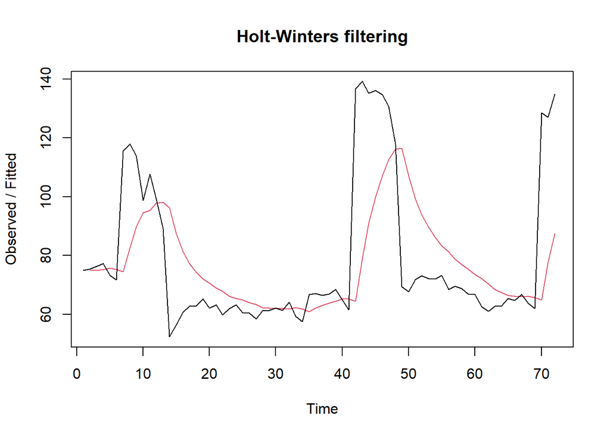

```r
#Cara 2 (fungsi Holtwinter)
ses.1<- HoltWinters(train.ts, gamma = FALSE, beta = FALSE, alpha = 0.2)
plot(ses.1)
```

```r
#ramalan
ramalan.1<- forecast(ses.1, h=72)
ramalan.1
```

```
##     Point Forecast    Lo 80    Hi 80    Lo 95    Hi 95
##  73       96.97275 67.96219 125.9833 52.60493 141.3406
##  74       96.97275 67.38767 126.5578 51.72627 142.2192
##  75       96.97275 66.82409 127.1214 50.86436 143.0811
##  76       96.97275 66.27086 127.6746 50.01826 143.9272
##  77       96.97275 65.72742 128.2181 49.18714 144.7583
##  78       96.97275 65.19327 128.7522 48.37024 145.5753
##  79       96.97275 64.66796 129.2775 47.56684 146.3787
##  80       96.97275 64.15105 129.7944 46.77629 147.1692
##  81       96.97275 63.64215 130.3033 45.99800 147.9475
##  82       96.97275 63.14091 130.8046 45.23142 148.7141
##  83       96.97275 62.64699 131.2985 44.47604 149.4695
##  84       96.97275 62.16008 131.7854 43.73137 150.2141
##  85       96.97275 61.67988 132.2656 42.99697 150.9485
##  86       96.97275 61.20613 132.7394 42.27243 151.6731
```

[output cut: 58 more lines]

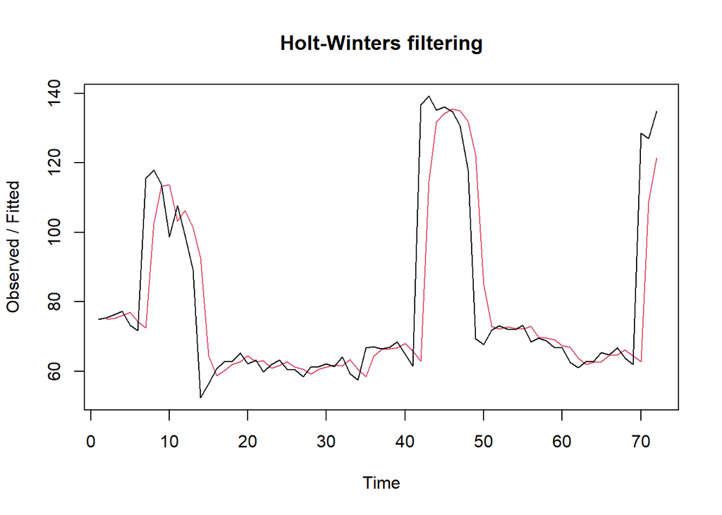

```r
ses.2<- HoltWinters(train.ts, gamma = FALSE, beta = FALSE, alpha = 0.7)
plot(ses.2)
```

```r
#ramalan
ramalan.2<- forecast(ses.2, h=72)
ramalan.2
```

```
##     Point Forecast      Lo 80    Hi 80       Lo 95    Hi 95
##  73       130.8689 109.958545 151.7792  98.8892857 162.8485
##  74       130.8689 105.344564 156.3932  91.8328121 169.9049
##  75       130.8689 101.445433 160.2923  85.8696053 175.8681
##  76       130.8689  98.005713 163.7320  80.6090069 181.1287
##  77       130.8689  94.893384 166.8444  75.8491112 185.8886
##  78       130.8689  92.029662 169.7081  71.4694266 190.2683
##  79       130.8689  89.363057 172.3747  67.3912055 194.3465
##  80       130.8689  86.857724 174.8800  63.5596291 198.1781
##  81       130.8689  84.487522 177.2502  59.9347179 201.8030
##  82       130.8689  82.232691 179.5051  56.4862514 205.2515
##  83       130.8689  80.077863 181.6599  53.1907265 208.5470
##  84       130.8689  78.010806 183.7269  50.0294366 211.7083
##  85       130.8689  76.021597 185.7161  46.9872033 214.7505
##  86       130.8689  74.102050 187.6357  44.0515098 217.6862
```

[output cut: 58 more lines]

Fungsi `HoltWinters` memiliki argumen yang sama dengan fungsi `ses()` . Argumen-argumen kedua fungsi dapat dilihat lebih lanjut dengan `?ses()` atau `?HoltWinters` .

Nilai parameter $\alpha$ dari kedua fungsi dapat dioptimalkan menyesuaikan dari *error*-nya paling minimumnya. Caranya adalah dengan membuat parameter $\alpha =$ `NULL` .

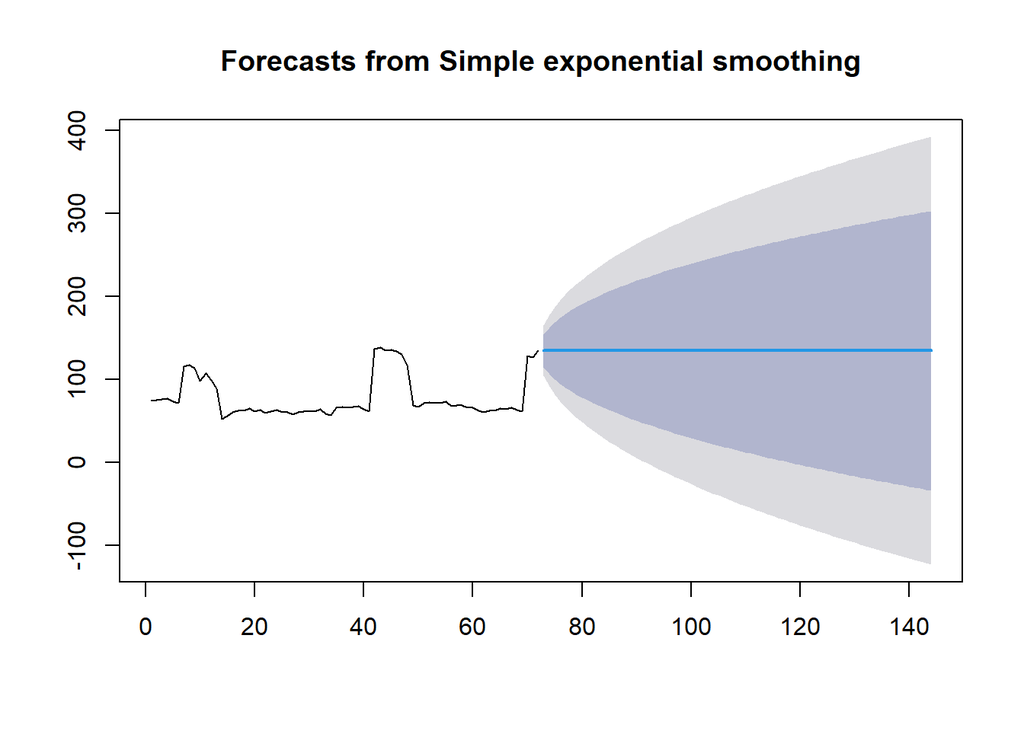

```r
#SES
ses.opt <- ses(train.ts, h = 72, alpha = NULL)
plot(ses.opt)
```

```r
ses.opt
```

```
##     Point Forecast       Lo 80    Hi 80        Lo 95    Hi 95
##  73       134.8992 115.0370872 154.7613  104.5227203 165.2757
##  74       134.8992 106.8113374 162.9871   91.9425217 177.8559
##  75       134.8992 100.4993087 169.2991   82.2891068 187.5093
##  76       134.8992  95.1779587 174.6204   74.1508042 195.6476
##  77       134.8992  90.4897246 179.3087   66.9807690 202.8176
##  78       134.8992  86.2512196 183.5472   60.4985350 209.2999
##  79       134.8992  82.3535010 187.4449   54.5374887 215.2609
##  80       134.8992  78.7255854 191.0728   48.9890707 220.8093
##  81       134.8992  75.3181673 194.4802   43.7778743 226.0205
##  82       134.8992  72.0953470 197.7031   38.8489960 230.9494
##  83       134.8992  69.0300233 200.7684   34.1609880 235.6374
##  84       134.8992  66.1011410 203.6973   29.6816490 240.1167
##  85       134.8992  63.2919558 206.5064   25.3853711 244.4130
##  86       134.8992  60.5888918 209.2095   21.2513914 248.5470
```

[output cut: 58 more lines]

```r
#Lamda Optimum Holt Winter
sesopt<- HoltWinters(train.ts, gamma = FALSE, beta = FALSE,alpha = NULL)
sesopt
```

```
## Holt-Winters exponential smoothing without trend and without seasonal component.
##
## Call:
## HoltWinters(x = train.ts, alpha = NULL, beta = FALSE, gamma = FALSE)
##
## Smoothing parameters:
##  alpha: 0.9999472
##  beta : FALSE
##  gamma: FALSE
##
## Coefficients:
##       [,1]
## a 134.8996
```

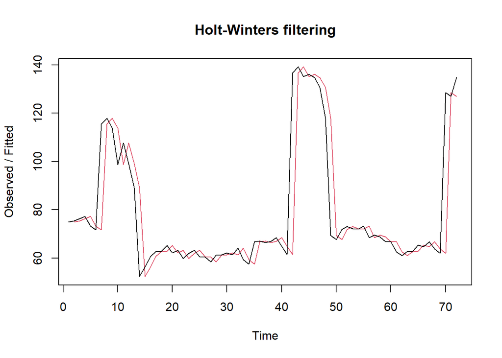

```r
plot(sesopt)
```

```r
#ramalan
ramalanopt<- forecast(sesopt, h=72)
ramalanopt
```

```
##     Point Forecast       Lo 80    Hi 80        Lo 95    Hi 95
##  73       134.8996 115.0674726 154.7317  104.5689903 165.2302
##  74       134.8996 106.8534855 162.9457   92.0067810 177.7924
##  75       134.8996 100.5505721 169.2486   82.3673068 187.4318
##  76       134.8996  95.2369368 174.5622   74.2408029 195.5584
##  77       134.8996  90.5555141 179.2436   67.0811847 202.7180
##  78       134.8996  86.3231752 183.4760   60.6083810 209.1908
##  79       134.8996  82.4311322 187.3680   54.6560148 215.1431
##  80       134.8996  78.8085029 190.9907   49.1156814 220.6835
##  81       134.8996  75.4060523 194.3931   43.9120822 225.8871
##  82       134.8996  72.1879323 197.6112   38.9903924 230.8088
##  83       134.8996  69.1270807 200.6721   34.3092238 235.4899
##  84       134.8996  66.2024725 203.5967   29.8364216 239.9627
##  85       134.8996  63.3973878 206.4018   25.5464147 244.2527
##  86       134.8996  60.6982700 209.1009   21.4184703 248.3807
```

[output cut: 58 more lines]

Setelah dilakukan peramalan, akan dilakukan perhitungan keakuratan hasil peramalan. Perhitungan akurasi ini dilakukan baik pada data latih dan data uji.

#### Akurasi Data Latih

Perhitungan akurasi data dapat dilakukan dengan cara langsung maupun manual. Secara langsung, nilai akurasi dapat diambil dari objek yang tersimpan pada hasil SES, yaitu *sum of squared errors* (SSE). Nilai akurasi lain dapat dihitung pula dari nilai SSE tersebut.

```r
#Keakuratan Metode
#Pada data training
SSE1<-ses.1$SSE
MSE1<-ses.1$SSE/length(train.ts)
RMSE1<-sqrt(MSE1)

akurasi1 <- matrix(c(SSE1,MSE1,RMSE1))
row.names(akurasi1)<- c("SSE", "MSE", "RMSE")
colnames(akurasi1) <- c("Akurasi lamda=0.2")
akurasi1
```

```
##      Akurasi lamda=0.2
## SSE        36042.09733
## MSE          500.58469
## RMSE          22.37375
```

```r
SSE2<-ses.2$SSE
MSE2<-ses.2$SSE/length(train.ts)
RMSE2<-sqrt(MSE2)

akurasi2 <- matrix(c(SSE2,MSE2,RMSE2))
row.names(akurasi2)<- c("SSE", "MSE", "RMSE")
colnames(akurasi2) <- c("Akurasi lamda=0.7")
akurasi2
```

```
##      Akurasi lamda=0.7
## SSE        18725.81939
## MSE          260.08082
## RMSE          16.12702
```

```r
#Cara Manual
fitted1<-ramalan.1$fitted
sisaan1<-ramalan.1$residuals
head(sisaan1)
```

```
## Time Series:
## Start = 1
## End = 6
## Frequency = 1
## [1]      NA  0.5000  1.4000  2.0200 -2.3840 -3.5072
```

```r
resid1<- ramalan.1$fitted
head(resid1)
```

```
## Time Series:
## Start = 1
## End = 6
## Frequency = 1
## [1]      NA 74.9000 75.0000 75.2800 75.6840 75.2072
```

```r
#Cara Manual
SSE.1=sum(sisaan1[2:length(train.ts)]^2)
SSE.1
```

```
## [1] 36042.1
```

```r
MSE.1 = SSE.1/length(train.ts)
MSE.1
```

```
## [1] 500.5847
```

```r
MAPE.1 = sum(abs(sisaan1[2:length(train.ts)]/train.ts[2:length(train.ts)])*
               100)/length(train.ts)
MAPE.1
```

```
## [1] 16.25704
```

```r
akurasi.1 <- matrix(c(SSE.1,MSE.1,MAPE.1))
row.names(akurasi.1)<- c("SSE", "MSE", "MAPE")
colnames(akurasi.1) <- c("Akurasi lamda=0.2")
akurasi.1
```

```
##      Akurasi lamda=0.2
## SSE        36042.09733
## MSE          500.58469
## MAPE          16.25704
```

```r
fitted2<-ramalan.2$fitted
sisaan2<-ramalan.2$residuals
head(sisaan2)
```

```
## Time Series:
## Start = 1
## End = 6
## Frequency = 1
## [1]       NA  0.50000  1.15000  1.24500 -3.62650 -2.68795
```

```r
resid2<-ramalan.2$fitted
head(resid2)
```

```
## Time Series:
## Start = 1
## End = 6
## Frequency = 1
## [1]       NA 74.90000 75.25000 76.05500 76.92650 74.38795
```

```r
SSE.2=sum(sisaan2[2:length(train.ts)]^2)
SSE.2
```

```
## [1] 18725.82
```

```r
MSE.2 = SSE.2/length(train.ts)
MSE.2
```

```
## [1] 260.0808
```

```r
MAPE.2 = sum(abs(sisaan2[2:length(train.ts)]/train.ts[2:length(train.ts)])*
               100)/length(train.ts)
MAPE.2
```

```
## [1] 8.354585
```

```r
akurasi.2 <- matrix(c(SSE.2,MSE.2,MAPE.2))
row.names(akurasi.2)<- c("SSE", "MSE", "MAPE")
colnames(akurasi.2) <- c("Akurasi lamda=0.7")
akurasi.2
```

```
##      Akurasi lamda=0.7
## SSE       18725.819390
## MSE         260.080825
## MAPE          8.354585
```

#### Akurasi Data Uji

Akurasi data uji dapat dihitung dengan cara yang hampir sama dengan perhitungan akurasi data latih.

```r
selisih1<-ramalan.1$mean-testing$PowerConsumed
SSEtesting1<-sum(selisih1^2)
MSEtesting1<-SSEtesting1/length(testing)

selisih2<-ramalan.2$mean-testing$PowerConsumed
SSEtesting2<-sum(selisih2^2)
MSEtesting2<-SSEtesting2/length(testing)

selisihopt<-ramalanopt$mean-testing$PowerConsumed
SSEtestingopt<-sum(selisihopt^2)
MSEtestingopt<-SSEtestingopt/length(testing)

akurasitesting1 <- matrix(c(SSEtesting1,SSEtesting2,SSEtestingopt))
row.names(akurasitesting1)<- c("SSE1", "SSE2", "SSEopt")
akurasitesting1
```

```
##             [,1]
## SSE1    70036.07
## SSE2   242119.80
## SSEopt 273589.65
```

```r
akurasitesting2 <- matrix(c(MSEtesting1,MSEtesting2,MSEtestingopt))
row.names(akurasitesting2)<- c("MSE1", "MSE2", "MSEopt")
akurasitesting2
```

```
##             [,1]
## MSE1    35018.03
## MSE2   121059.90
## MSEopt 136794.83
```

Selain dengan cara di atas, perhitungan nilai akurasi dapat menggunakan fungsi `accuracy()` dari *package* `forecast` . Penggunaannya yaitu dengan menuliskan `accuracy(hasil ramalan, kondisi aktual)` . Contohnya adalah sebagai berikut.

```r
#cara lain
accuracy(ramalanopt,testing$PowerConsumed)
```

```
##                       ME     RMSE       MAE         MPE      MAPE     MASE
## Training set   0.8451091 15.38893  6.470484  -0.5405664  7.376627 1.000009
## Test set     -56.2343002 61.64297 56.442692 -85.1190438 85.270191 8.723185
##                    ACF1
## Training set 0.03294473
## Test set             NA
```

## Pemulusan Data Musiman

Pertama impor kembali data baru untuk latihan data musiman.

```r
#Import data
library(rio)
data2 <- import("https://raw.githubusercontent.com/DindaKhamila/mpdw/main/Data/DataTugas.csv")
data2.ts <- ts(data2$PowerConsumed)
```

Selanjutnya melakukan pembagian data dan mengubahnya menjadi data deret waktu.

```r
#membagi data menjadi training dan testing
training<-data2[1:287,2]
testing<-data2[288:359,2]
training.ts<-ts(training, frequency = 13)
testing.ts<-ts(testing, frequency = 13)
```

Kemudian akan dilakukan eskplorasi dengan plot data deret waktu sebagai berikut.

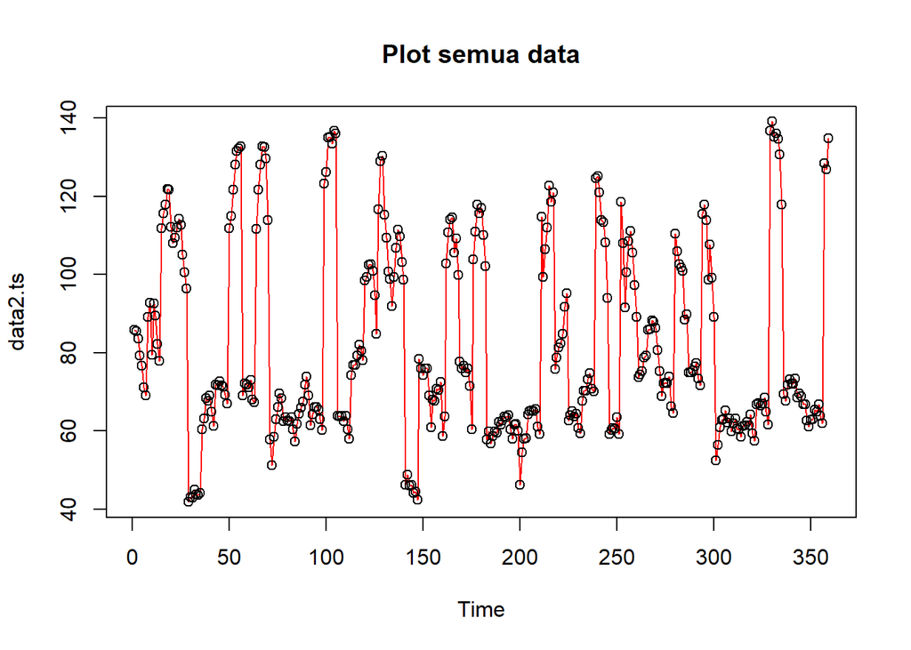

```r
#Membuat plot time series
plot(data2.ts, col="red",main="Plot semua data")
points(data2.ts)
```

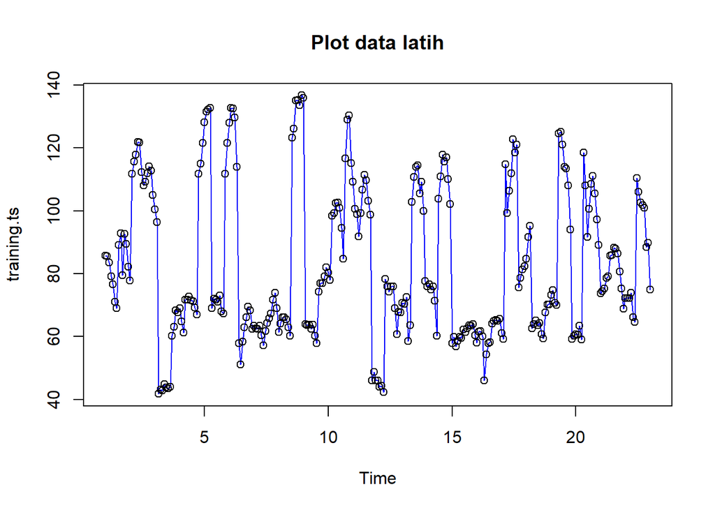

```r
plot(training.ts, col="blue",main="Plot data latih")
points(training.ts)
```

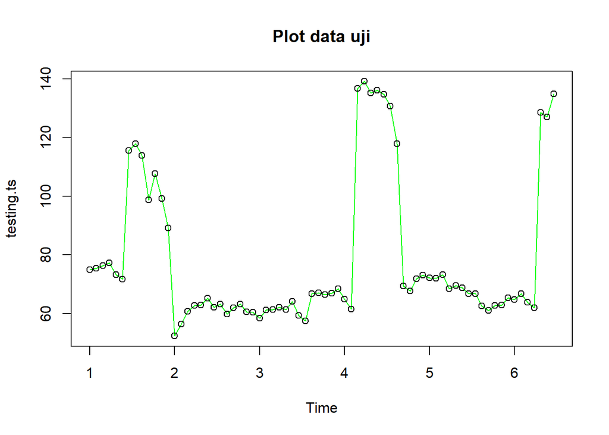

```r
plot(testing.ts, col="green",main="Plot data uji")
points(testing.ts)
```

Metode Holt-Winter untuk peramalan data musiman menggunakan tiga persamaan pemulusan yang terdiri atas persamaan untuk level $(L_t)$, trend $(B_t)$, dan komponen seasonal / musiman $(S_t)$ dengan parameter pemulusan berupa $\alpha$, $\beta$, dan $\gamma$. Metode Holt-Winter musiman terbagi menjadi dua, yaitu metode aditif dan metode multiplikatif. Perbedaan persamaan dan contoh datanya adalah sebagai berikut.

[figure not shown]

Pemulusan data musiman dengan metode Winter dilakukan menggunakan fungsi `HoltWinters()` dengan memasukkan argumen tambahan, yaitu `gamma()` dan `seasonal()` . Arguman `seasonal()` diinisialisasi menyesuaikan jenis musiman, aditif atau multiplikatif.

### Winter Multiplikatif

Model multiplikatif digunakan cocok digunakan jika plot data asli menunjukkan fluktuasi musiman yang bervariasi.

#### Pemulusan

```r
#Pemulusan dengan winter multiplikatif
winter2 <- HoltWinters(training.ts,alpha=0.2,beta=0.1,gamma=0.3,seasonal = "multiplicative")
winter2$fitted
```

```
## Time Series:
## Start = c(2, 1)
## End = c(23, 1)
## Frequency = 13
##                xhat     level       trend    season
##  2.000000  61.72342  78.63702  2.40539307 0.7616187
##  2.076923  95.04317  85.26410  2.82756166 1.0789121
##  2.153846 103.94384  91.19791  3.13818628 1.1018459
##  2.230769 109.50594  96.45185  3.34976143 1.0972362
##  2.307692 117.08772 101.33165  3.50276505 1.1168825
##  2.384615 119.85488 105.69615  3.58893847 1.0967177
##  2.461538 102.69950 109.62156  3.62258647 0.9068857
##  2.538462 127.06870 115.33934  3.83210563 1.0662680
##  2.615385 128.91028 115.59473  3.47443378 1.0826504
##  2.692308 106.82898 115.44652  3.11216943 0.9010641
##  2.769231 124.71472 119.68425  3.22472568 1.0146917
##  2.846154 116.79127 120.83648  3.01747612 0.9429757
##  2.923077 104.79450 122.98622  2.93070241 0.8322511
##  3.000000 104.00722 125.96631  2.93564079 0.8068708
##  3.076923 146.98104 128.03261  2.84870688 1.1230101
##  3.153846 140.02305 121.87320  1.94789509 1.1308498
##  3.230769 119.15204 106.44955  0.21074031 1.1171172
##  3.307692 103.63857  93.04452 -1.15083644 1.1278096
##  3.384615  86.84388  81.12261 -2.22794334 1.1007573
##  3.461538  63.27542  71.27376 -2.99003470 0.9266545
##  3.538462  62.28847  64.08034 -3.41037298 1.0266772
##  3.615385  55.46311  57.00991 -3.77637838 1.0418829
##  3.692308  42.88058  51.05227 -3.99450479 0.9112329
##  3.769231  46.97615  50.88103 -3.61217845 0.9938078
##  3.846154  44.17664  50.53384 -3.28567977 0.9349918
##  3.923077  41.35082  52.42967 -2.76752853 0.8326427
##  4.000000  43.08007  55.96717 -2.13702555 0.8002965
##  4.076923  60.19498  60.30773 -1.48926744 1.0234029
##  4.153846  53.03525  59.71840 -1.39927312 0.9093971
##  4.230769  54.23928  60.11477 -1.21970903 0.9209478
##  4.307692  58.66022  62.70868 -0.83834704 0.9481154
##  4.384615  61.46465  64.62101 -0.56327962 0.9595197
##  4.461538  56.40526  66.39960 -0.32909269 0.8537133
##  4.538462  66.00575  69.63018  0.02687543 0.9475816
##  4.615385  70.09506  70.77448  0.13861781 0.9884642
```

[output cut: 224 more lines]

```
## 21.923077  70.73654  79.47240 -0.70116139 0.8979995
## 22.000000  65.73989  78.36222 -0.74206422 0.8469436
## 22.076923  67.88228  79.14566 -0.58951303 0.8641243
## 22.153846  73.73578  79.57862 -0.48726574 0.9322862
## 22.230769  68.62788  78.76189 -0.52021222 0.8771268
## 22.307692  88.11839  79.44381 -0.39999874 1.1148044
## 22.384615  81.67868  75.11158 -0.79322273 1.0990378
## 22.461538  74.93882  71.21042 -1.10401606 1.0689297
## 22.538462  82.90342  76.76001 -0.43865553 1.0862415
## 22.615385  88.74498  80.57392 -0.01339873 1.1015938
## 22.692308  87.69494  83.09413  0.23996187 1.0523297
## 22.769231  87.32300  86.01482  0.50803493 1.0092477
## 22.846154  83.84605  89.21338  0.77708688 0.9317215
## 22.923077  81.95823  90.96800  0.87484029 0.8923747
## 23.000000  82.01817  93.60034  1.05059098 0.8665331
```

```r
xhat2 <- winter2$fitted[,2]

winter2.opt<- HoltWinters(training.ts, alpha= NULL,  beta = NULL, gamma = NULL, seasonal = "multiplicative")
winter2.opt$fitted
```

```
## Time Series:
## Start = c(2, 1)
## End = c(23, 1)
## Frequency = 13
##                xhat     level     trend    season
##  2.000000  61.72342  78.63702 2.4053931 0.7616187
##  2.076923 110.41830  99.80044 2.5418082 1.0789121
##  2.153846 116.82914 103.48030 2.5500845 1.1018459
##  2.230769 118.04281 105.03907 2.5428753 1.0972362
##  2.307692 122.86637 107.46628 2.5420342 1.1168825
##  2.384615 122.58657 109.23943 2.5364425 1.0967177
##  2.461538 103.01198 111.05750 2.5312183 0.9068857
##  2.538462 133.48469 122.59199 2.5966934 1.0662680
##  2.615385 115.18472 103.94919 2.4422321 1.0826504
##  2.692308  93.68209 101.56118 2.4071048 0.9010641
##  2.769231 126.30171 121.93522 2.5377669 1.0146917
##  2.846154 109.70126 113.87450 2.4606908 0.9429757
##  2.923077 101.23704 119.16117 2.4812424 0.8322511
##  3.000000  99.91631 125.66039 2.5104625 0.7795557
##  3.076923 141.91204 128.83622 2.5153014 1.0803989
##  3.153846 105.82817  93.91691 2.2430632 1.1005429
##  3.230769  50.82423  44.45940 1.8670779 1.0970883
##  3.307692  46.74646  40.06978 1.8215770 1.1158975
##  3.384615  44.52079  38.82821 1.7993006 1.0958288
##  3.461538  39.11383  40.93502 1.8015370 0.9152311
##  3.538462  51.03548  47.28664 1.8346268 1.0389691
##  3.615385  47.85185  42.67602 1.7877546 1.0761986
##  3.692308  39.58131  41.36575 1.7652247 0.9177004
##  3.769231  65.29105  63.19382 1.9111290 1.0028584
##  3.846154  61.61714  63.25204 1.8976539 0.9457779
##  3.923077  61.38784  71.52286 1.9440019 0.8355855
##  4.000000  64.01608  80.07353 1.9920480 0.7800601
##  4.076923  92.15026  87.74330 2.0333384 1.0264393
##  4.153846  63.89393  66.09785 1.8611377 0.9401837
##  4.230769  72.34142  65.41272 1.8426203 1.0756236
##  4.307692  75.84623  66.80803 1.8393673 1.1048669
##  4.384615  73.62968  65.31256 1.8151152 1.0968603
##  4.461538  63.15662  66.37447 1.8096376 0.9262659
##  4.538462  79.66212  76.28461 1.8685474 1.0193078
##  4.615385  77.48243  70.86291 1.8155301 1.0660993
```

[output cut: 224 more lines]

```
## 21.923077  76.64001  84.35886 0.3485176 0.9047620
## 22.000000  63.90262  77.10518 0.2932317 0.8256321
## 22.076923  70.63541  86.32912 0.3581791 0.8148299
## 22.153846  76.23750  88.50270 0.3713813 0.8578148
## 22.230769  70.83139  84.69145 0.3409637 0.8329929
## 22.307692  87.86332  88.30605 0.3647708 0.9908932
## 22.384615  68.61199  69.24277 0.2234829 0.9877025
## 22.461538  64.60938  65.85660 0.1972322 0.9781321
## 22.538462 107.78496 107.74631 0.5004350 0.9957340
## 22.615385 108.45223 106.65374 0.4888502 1.0122233
## 22.692308  98.80731 102.09260 0.4521247 0.9635533
## 22.769231  98.65464 105.30478 0.4721969 0.9326665
## 22.846154  96.76317 107.91636 0.4877553 0.8926152
## 22.923077  89.80998 100.07809 0.4272054 0.8935845
## 23.000000  84.40495 100.49537 0.4271332 0.8363342
```

```r
xhat2.opt <- winter2.opt$fitted[,2]
```

#### Peramalan

```r
#Forecast
forecast2 <- predict(winter2, n.ahead = 49)
forecast2.opt <- predict(winter2.opt, n.ahead = 49)
```

#### Plot Deret Waktu

[figure not shown]

```r
#Plot time series
plot(training.ts,main="Winter 0.2;0.1;0.1",type="l",col="black",
     xlim=c(1,25),pch=12)
lines(xhat2,type="l",col="red")
lines(xhat2.opt,type="l",col="blue")
lines(forecast2,type="l",col="red")
lines(forecast2.opt,type="l",col="blue")
legend("topleft",c("Actual Data",expression(paste(winter2)),
                   expression(paste(winter2.opt))),cex=0.5,
       col=c("black","red","blue"),lty=1)
```

#### Akurasi Data Latih

```r
#Akurasi data training
SSE2<-winter2$SSE
MSE2<-winter2$SSE/length(training.ts)
RMSE2<-sqrt(MSE2)
akurasi1 <- matrix(c(SSE2,MSE2,RMSE2))
row.names(akurasi1)<- c("SSE2", "MSE2", "RMSE2")
colnames(akurasi1) <- c("Akurasi lamda=0.2")
akurasi1
```

```
##       Akurasi lamda=0.2
## SSE2       169898.46357
## MSE2          591.98071
## RMSE2          24.33065
```

```r
SSE2.opt<-winter2.opt$SSE
MSE2.opt<-winter2.opt$SSE/length(training.ts)
RMSE2.opt<-sqrt(MSE2.opt)
akurasi1.opt <- matrix(c(SSE2.opt,MSE2.opt,RMSE2.opt))
row.names(akurasi1.opt)<- c("SSE2.opt", "MSE2.opt", "RMSE2.opt")
colnames(akurasi1.opt) <- c("Akurasi")
akurasi1.opt
```

```
##               Akurasi
## SSE2.opt  74942.44579
## MSE2.opt    261.12350
## RMSE2.opt    16.15932
```

```r
akurasi2.train = data.frame(Model_Winter = c("Winter 1","winter2 optimal"),
                            Nilai_SSE=c(SSE2,SSE2.opt),
                            Nilai_MSE=c(MSE2,MSE2.opt),Nilai_RMSE=c(RMSE2,RMSE2.opt))
akurasi2.train
```

```
##      Model_Winter Nilai_SSE Nilai_MSE Nilai_RMSE
## 1        Winter 1 169898.46  591.9807   24.33065
## 2 winter2 optimal  74942.45  261.1235   16.15932
```

#### Akurasi Data Uji

```r
#Akurasi Data Testing
forecast2<-data.frame(forecast2)
testing.ts<-data.frame(testing.ts)
selisih2<-testing.ts
SSEtesting2<-sum(selisih2^2)
MSEtesting2<-SSEtesting2/length(testing.ts)

forecast2.opt<-data.frame(forecast2.opt)
selisih2.opt<-testing.ts
SSEtesting2.opt<-sum(selisih2.opt^2)
MSEtesting2.opt<-SSEtesting2.opt/length(testing.ts)
```